# Lecture 22 - Subsetting and Pivoting

In the previous class ...

- ... we introduced parsing and
- ... data manipulation with time

In this class we will ...

- Plot multiple series
- Compute growth rates
- Use merge/pivot to change layout of data

# I. Import Libraries and Data

Import libraries

```python
# "pandas" processes datasets
# "maplotlib.pyplot" generates graphs

import pandas as pd
import matplotlib.pyplot as plt
```

Import data

```python
financial      = pd.read_csv("data_raw/financial.csv")
```

Parse data and sort dataset

```python
financial["date"] = pd.to_datetime(financial["date_str"])
financial         = financial.sort_values("date",ascending = True)
```

Plot multiple columns

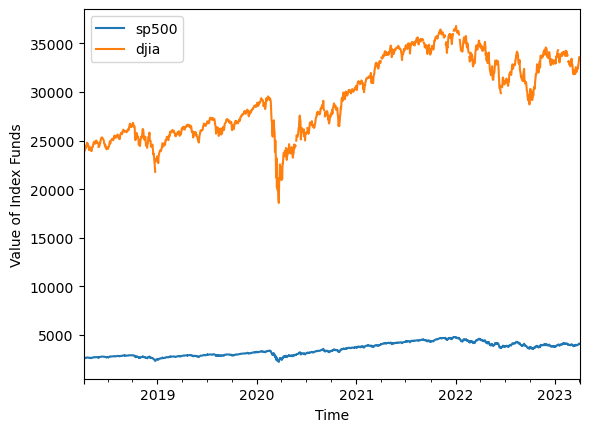

```python
# Enter the x-axis column and y-axis columns you
# wish to include. Specify the x-axis column with "set_index()"
# This applies to any line plot, with or without dates
# The legend is the box with the name of the lines
# If you drop the ".legend()" command this will assign
# the default column names to the legend.


(financial[["date","sp500","djia"]]
    .set_index("date").plot())
plt.xlabel("Time")
plt.ylabel("Value of Index Funds")
#plt.legend(["S&P 500","Dow Jones"])
```

Remarks ...

- The S\&P 500 and Dow Jones have different units.
- More sensible to compare their growth rate!

# II. Time Difference/Growth

Change between periods

```python
# First sort columns by date. The second computes the
# differences in "sp500" between each row and the one before it
# By convention, the first row gets a missing value because
# there is nothing to compare. For this to work, it's important
# that the dataset is sorted.

financial["diff_sp500"] = financial["sp500"].diff()

display(financial[["sp500","diff_sp500" ]])
```

|  | sp500 | diff_sp500 |
| --- | --- | --- |
| 0 | 2644.69 | NaN |
| 1 | 2662.84 | 18.15 |
| 2 | 2604.47 | -58.37 |
| 3 | 2613.16 | 8.69 |
| 4 | 2656.87 | 43.71 |
| ... | ... | ... |
| 1300 | 4027.81 | 56.54 |
| 1301 | 4050.83 | 23.02 |
| 1302 | 4109.31 | 58.48 |
| 1303 | 4124.51 | 15.20 |
| 1304 | 4100.60 | -23.91 |

1305 rows × 2 columns

Compute lag + percentage growth

```python
# ".shif(1)" compute a new column with the value of "sp500"
# one period before. By convention the first column is assigned
# a missing value
# We can combine ".diff()" and ".shift()" to compute growth rates

financial["lag_sp500"]    = financial["sp500"].shift(1)
financial["growth_sp500"] = financial["diff_sp500"]* 100/financial["lag_sp500"]

display(financial[["sp500","lag_sp500","diff_sp500","growth_sp500"]])
```

|  | sp500 | lag_sp500 | diff_sp500 | growth_sp500 |
| --- | --- | --- | --- | --- |
| 0 | 2644.69 | NaN | NaN | NaN |
| 1 | 2662.84 | 2644.69 | 18.15 | 0.686281 |
| 2 | 2604.47 | 2662.84 | -58.37 | -2.192021 |
| 3 | 2613.16 | 2604.47 | 8.69 | 0.333657 |
| 4 | 2656.87 | 2613.16 | 43.71 | 1.672687 |
| ... | ... | ... | ... | ... |
| 1300 | 4027.81 | 3971.27 | 56.54 | 1.423726 |
| 1301 | 4050.83 | 4027.81 | 23.02 | 0.571526 |
| 1302 | 4109.31 | 4050.83 | 58.48 | 1.443655 |
| 1303 | 4124.51 | 4109.31 | 15.20 | 0.369892 |
| 1304 | 4100.60 | 4124.51 | -23.91 | -0.579705 |

1305 rows × 4 columns

Time between dates

```python
# In the financial data example, the price of the stock portfolios isn't recorded
# on weekends. Sometimes it's important to account for these differences in the
# legnth between time periods, when accounting for growth rates
# Can compute dt.days, dt.months, dt.year, etc.

financial["diff_date"]  = financial["date"]-financial["date"].shift(1)
financial["count_days"] = financial["diff_date"].dt.days
financial["count_days"]
```

```
0       NaN
1       1.0
2       1.0
3       3.0
4       1.0
       ...
1300    1.0
1301    1.0
1302    1.0
1303    3.0
1304    1.0
Name: count_days, Length: 1305, dtype: float64
```

Plot growth

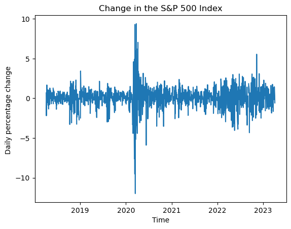

```python
plt.plot("date", "growth_sp500",
          data = financial.sort_values("date",ascending = True))
plt.xlabel("Time")
plt.ylabel("Daily percentage change ")
plt.title("Change in the S&P 500 Index")
```

Try it yourself!

- Compute a column with the growth of the Dow Jones
- Plot the growth of the S&P 500 and Dow Jones in a  
  single plot

[figure not shown]

```python
# Write your own code
```

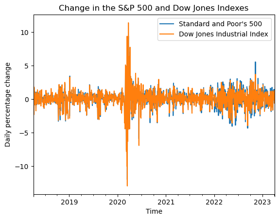

```python
financial[["date","growth_sp500","growth_djia"]].set_index("date").plot()
plt.xlabel("Time")
plt.ylabel("Daily percentage change")
plt.title("Change in the S&P 500 and Dow Jones Indexes")
plt.legend(["Standard and Poor's 500","Dow Jones Industrial Index"])
```

# III. Subsetting with time data

Subsetting before/after

```python
# Since the "date" column has a time format, Python
# will interpret "2019-01-01" as a date inside the query command
# Note: remember that you have to use single quotations for ".query()"

subset_before  = financial.query('date >= "2019-01-01" ')
subset_after   = financial.query('date <= "2020-01-01" ')
```

Obtain a subset between two dates

```python
# This command applies the function ".between()" to the column

subset_between = financial.query('date.between("2020-03-01","2020-05-01")')
```

Flag observations

```python
financial["bool_period"]  = financial["date"].between("2020-03-01","2020-05-01")
financial["bool_example"] = financial["growth_sp500"] > 5
```

Plot results

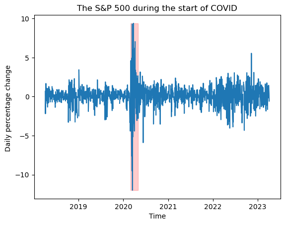

```python
# Create a line plot
plt.plot("date", "growth_sp500", data = financial)
plt.xlabel("Time")
plt.ylabel("Daily percentage change ")
plt.title("The S&P 500 during the start of COVID")

# Add a shaded region wth a rectangle
# "x" is the x-coordinates, "y1" and "y2" are the lower
# and upper bounds of the rectangle. We can set this
# to be the minimum and meximum of the outcome.
# we use "where" to test a logical condition

vec_y = financial["growth_sp500"]
plt.fill_between(x= financial["date"],
                 y1 = vec_y.min(),
                 y2 = vec_y.max(),
                 where = financial["bool_period"],
                 alpha = 0.2,color = "red")

plt.show()
```

Try it yourself!

- Generate a plot of the daily growth of the Dow Jones
- Highlight regions where there was growth higher than 4\%  
  or below -4\%

[figure not shown]

```python
# Write your own code
```

# IV. Wide and Long Format

Data can come in a wide variety of formats

- Few rows, multiple columns (wide)
- Stacked rows, few columns (long)
- The **information** is the same!

Wide to long

$\quad$

[figure not shown]

```python
financial_long = pd.melt(financial,
                         var_name   = "portfolio_type",
                         value_name = "portfolio_value",
                         id_vars='date',
                         value_vars=['sp500','djia'])

display(financial_long)
```

|  | date | portfolio_type | portfolio_value |
| --- | --- | --- | --- |
| 0 | 2018-04-04 | sp500 | 2644.69 |
| 1 | 2018-04-05 | sp500 | 2662.84 |
| 2 | 2018-04-06 | sp500 | 2604.47 |
| 3 | 2018-04-09 | sp500 | 2613.16 |
| 4 | 2018-04-10 | sp500 | 2656.87 |
| ... | ... | ... | ... |
| 2605 | 2023-03-29 | djia | 32717.60 |
| 2606 | 2023-03-30 | djia | 32859.03 |
| 2607 | 2023-03-31 | djia | 33274.15 |
| 2608 | 2023-04-03 | djia | 33601.15 |
| 2609 | 2023-04-04 | djia | 33402.38 |

2610 rows × 3 columns

Long to wide

$\quad$

[figure not shown]

```python
financial_wide = (pd.pivot(financial_long,
                           index = 'date',
                           columns = 'portfolio_type',
                           values =  'portfolio_value'))

financial_wide

# If you also want the index to be part of the dataset add
# ".reset_index()" to the end of the previous command
```

| portfolio_type date | djia | sp500 |
| --- | --- | --- |
| 2018-04-04 | 24264.30 | 2644.69 |
| 2018-04-05 | 24505.22 | 2662.84 |
| 2018-04-06 | 23932.76 | 2604.47 |
| 2018-04-09 | 23979.10 | 2613.16 |
| 2018-04-10 | 24408.00 | 2656.87 |
| ... | ... | ... |
| 2023-03-29 | 32717.60 | 4027.81 |
| 2023-03-30 | 32859.03 | 4050.83 |
| 2023-03-31 | 33274.15 | 4109.31 |
| 2023-04-03 | 33601.15 | 4124.51 |
| 2023-04-04 | 33402.38 | 4100.60 |

1305 rows × 2 columns

Try it yourself!

- Convert the "growth_sp500" and  
  "growth_djia" to long format

```python
# Write your own code
```